# Food insecurity explore

Dan Killian

10/26/2021

# 1 Introduction

The South Sudan Monitoring and Evaluation Support Project (MESP) is conducting a household resilience survey in 13 counties. The purpose of this household survey is to obtain baseline data in the target areas for the indicators included in the Mission’s Performance Management Plan (PMP) and the Community Roadmap, in support of USAID/South Sudan’s Strategic Framework (2020-2024).

MESP has completed data collection in six counties, and as of October 2021 is carrying out data collection in the remaining seven counties. The study team is currently reviewing the data from six counties in advance of analysis of the full set of 13 counties. This document is one of a series of documents to review various measures and indices relating to resilience.

# 2 Food insecurity

Food insecurity is the lack of confidence that the household will consistently maintain the caloric and dietary needs of its members. The South Sudan resilience baseline asks questions about food insecurity across two different temporal windows: 12 months and four weeks. The following survey items address the issue of food insecurity.

```r
fies <- dat %>%
  select(q_422:q_429)

svy_disag <- function(design, disaggregate, item, varname, label) {
  temp <- design %>%
    group_by({{disaggregate}}) %>%
    summarize(Value=survey_mean({{item}}, na.rm=T)) %>%
    mutate(#item={{item}},
           var_name={{varname}},
           label={{label}},
           lower=Value-1.96*Value_se,
           upper=Value+1.96*Value_se)
  temp
}

q422 <- svy_disag(svyrdat, "", q_422, "worried", "Worried about not enough to eat") %>%
  select(4,5,2,6,7)

#q422

q423 <- svy_disag(svyrdat, "", q_423, "unhealthy", "Unable to eat healthy") %>%
  select(4,5,2,6,7)

#q423

q424 <- svy_disag(svyrdat, "", q_424, "few_foods", "Ate few kinds of foods") %>%
  select(4,5,2,6,7)

#q424

q425 <- svy_disag(svyrdat, "", q_425, "skip", "Skipped a meal") %>%
  select(4,5,2,6,7)

#q425

q426 <- svy_disag(svyrdat, "", q_426, "ate_less", "Ate less than needed") %>%
  select(4,5,2,6,7)

#q426

q427 <- svy_disag(svyrdat, "", q_427, "no_food", "Did not have food") %>%
  select(4,5,2,6,7)

#q427

q428 <- svy_disag(svyrdat, "", q_428, "not_eat", "Did not eat") %>%
  select(4,5,2,6,7)

#q428

q429 <- svy_disag(svyrdat, "", q_429, "fast", "Went a day without eating") %>%
  select(4,5,2,6,7)

#q429

fies_items <- do.call(rbind,
                      list(q422,
                           q423,
                           q424,
                           q425,
                           q426,
                           q427,
                           q428,
                           q429))


#fies_items

fies_items_gt <- fies_items %>%
  gt() %>%
  fmt_percent(3:5,
              decimals=1)

fies_items_gt
```

| var_name | label | Value | lower | upper |
| --- | --- | --- | --- | --- |
| worried | Worried about not enough to eat | 95.2% | 93.5% | 97.0% |
| unhealthy | Unable to eat healthy | 96.8% | 95.7% | 97.9% |
| few_foods | Ate few kinds of foods | 96.3% | 95.0% | 97.6% |
| skip | Skipped a meal | 96.3% | 95.0% | 97.6% |
| ate_less | Ate less than needed | 96.9% | 95.8% | 97.9% |
| no_food | Did not have food | 96.7% | 95.5% | 97.9% |
| not_eat | Did not eat | 97.3% | 96.2% | 98.3% |
| fast | Went a day without eating | 96.6% | 95.4% | 97.8% |

```r
f2 <- dat %>%
  select(q_430:q_435)

head(f2)
```

Table 2.1:

| q_430 | q_431 | q_432 | q_433 | q_434 | q_435 |
| --- | --- | --- | --- | --- | --- |
| 1 | 2 | 0 |  | 0 |  |
| 1 | 2 |  |  | 1 | 2 |
| 1 | 2 | 1 | 1 | 1 | 2 |
| 1 | 2 | 1 | 2 | 1 | 1 |
| 1 | 2 | 1 | 1 | 1 | 2 |
| 1 | 2 | 1 | 2 | 1 | 2 |

```r
map(f2, frq)
```

```
## $q_430
##
## Q 430: Was there ever no food to eat of any kind in your house because of lack o (x) <numeric>
## # total N=3563  valid N=3542  mean=0.91  sd=0.28
##
## Value |      Label |    N | Raw % | Valid % | Cum. %
## ----------------------------------------------------
##     0 |         No |  315 |  8.84 |    8.89 |   8.89
##     1 |        Yes | 3227 | 90.57 |   91.11 | 100.00
##     8 | Don't know |    0 |  0.00 |    0.00 | 100.00
##     9 |    Refused |    0 |  0.00 |    0.00 | 100.00
##  <NA> |       <NA> |   21 |  0.59 |    <NA> |   <NA>
##
##
## $q_431
##
## Q 431: How often did this happen in the past 4 weeks? (x) <numeric>
## # total N=3563  valid N=3216  mean=1.61  sd=0.68
##
## Value |                  Label |    N | Raw % | Valid % | Cum. %
## ----------------------------------------------------------------
##     1 |     Rarely (1-2 times) | 1609 | 45.16 |   50.03 |  50.03
##     2 | Sometimes (3-10 times) | 1252 | 35.14 |   38.93 |  88.96
##     3 |      Often (>10 times) |  355 |  9.96 |   11.04 | 100.00
##  <NA> |                   <NA> |  347 |  9.74 |    <NA> |   <NA>
##
##
## $q_432
##
## Q 432: Did you or any household member go to sleep at night hungry because there (x) <numeric>
## # total N=3563  valid N=3535  mean=0.90  sd=0.31
##
## Value |      Label |    N | Raw % | Valid % | Cum. %
## ----------------------------------------------------
##     0 |         No |  368 | 10.33 |   10.41 |  10.41
##     1 |        Yes | 3167 | 88.89 |   89.59 | 100.00
##     8 | Don't know |    0 |  0.00 |    0.00 | 100.00
##     9 |    Refused |    0 |  0.00 |    0.00 | 100.00
##  <NA> |       <NA> |   28 |  0.79 |    <NA> |   <NA>
##
```

[output cut: 24 more lines]

```
##     9 |    Refused |    0 |  0.00 |    0.00 | 100.00
##  <NA> |       <NA> |   26 |  0.73 |    <NA> |   <NA>
##
##
## $q_435
##
## Q 435: How often did this happen in the past 4 weeks? (x) <numeric>
## # total N=3563  valid N=3066  mean=1.66  sd=0.72
##
## Value |                  Label |    N | Raw % | Valid % | Cum. %
## ----------------------------------------------------------------
##     1 |     Rarely (1-2 times) | 1494 | 41.93 |   48.73 |  48.73
##     2 | Sometimes (3-10 times) | 1117 | 31.35 |   36.43 |  85.16
##     3 |      Often (>10 times) |  455 | 12.77 |   14.84 | 100.00
##  <NA> |                   <NA> |  497 | 13.95 |    <NA> |   <NA>
```

# 3 Analytical models

## 3.1 FAO models

```r
library(ltm)
library(eRm)
library(RM.weights)

names(dat)
```

```
##   [1] "country"                    "project"
##   [3] "survey_name"                "treat_phase"
##   [5] "record_id"                  "state"
##   [7] "county"                     "payam"
##   [9] "boma"                       "ea"
##  [11] "date"                       "month"
##  [13] "day"                        "year"
##  [15] "time_started"               "time_ended"
##  [17] "survey_minutes"             "survey_seconds"
##  [19] "latitude"                   "longitude"
##  [21] "q_101"                      "q_206"
##  [23] "head_hh"                    "hh_head_sex"
##  [25] "q_209"                      "q_210_b"
##  [27] "q_211"                      "q_212"
##  [29] "household_members"          "q_302"
```

[output cut: 219 more lines]

```r
names(fies_items)
```

```
## [1] "var_name" "label"    "Value"    "lower"    "upper"
```

```r
rash <- fies_items %>%
  select(1:8)
```

```
## Error: Can't subset columns that don't exist.
## x Locations 6, 7, and 8 don't exist.
## i There are only 5 columns.
```

```r
rash <- dat %>%
  select(q_422:q_429) %>%
#  as.data.frame() %>%
  map(., as.numeric) %>%
  as.data.frame() %>%
  na.omit()

rash <- map(rash, as.numeric) %>%
  as.matrix()

str(rash)
```

```
## List of 8
##  $ : num [1:3511] 1 1 1 1 1 1 1 1 1 1 ...
##  $ : num [1:3511] 1 1 1 1 1 1 1 1 1 1 ...
##  $ : num [1:3511] 1 1 1 1 1 1 1 1 1 1 ...
##  $ : num [1:3511] 1 1 1 1 1 1 1 1 1 1 ...
##  $ : num [1:3511] 1 1 1 1 1 1 1 1 1 1 ...
##  $ : num [1:3511] 1 1 1 1 1 1 1 1 1 1 ...
##  $ : num [1:3511] 1 1 1 1 1 1 1 0 1 1 ...
##  $ : num [1:3511] 1 1 1 1 1 1 1 1 1 1 ...
##  - attr(*, "dim")= int [1:2] 8 1
##  - attr(*, "dimnames")=List of 2
##   ..$ : chr [1:8] "q_422" "q_423" "q_424" "q_425" ...
##   ..$ : NULL
```

```r
rash2 <- dat %>%
  select(q_422:q_429, hh_wt)

head(rash)
```

```
##       [,1]
## q_422 numeric,3511
## q_423 numeric,3511
## q_424 numeric,3511
## q_425 numeric,3511
## q_426 numeric,3511
## q_427 numeric,3511
```

```r
r1 <- RM.w(rash)
```

```
## Error in rowSums(.data): 'x' must be numeric
```

```r
str(rash)
```

```
## List of 8
##  $ : num [1:3511] 1 1 1 1 1 1 1 1 1 1 ...
##  $ : num [1:3511] 1 1 1 1 1 1 1 1 1 1 ...
##  $ : num [1:3511] 1 1 1 1 1 1 1 1 1 1 ...
##  $ : num [1:3511] 1 1 1 1 1 1 1 1 1 1 ...
##  $ : num [1:3511] 1 1 1 1 1 1 1 1 1 1 ...
##  $ : num [1:3511] 1 1 1 1 1 1 1 1 1 1 ...
##  $ : num [1:3511] 1 1 1 1 1 1 1 0 1 1 ...
##  $ : num [1:3511] 1 1 1 1 1 1 1 1 1 1 ...
##  - attr(*, "dim")= int [1:2] 8 1
##  - attr(*, "dimnames")=List of 2
##   ..$ : chr [1:8] "q_422" "q_423" "q_424" "q_425" ...
##   ..$ : NULL
```

```r
r1
```

```
## Error in eval(expr, envir, enclos): object 'r1' not found
```

```r
summary(r1)
```

```
## Error in h(simpleError(msg, call)): error in evaluating the argument 'object' in selecting a method for function 'summary': object 'r1' not found
```

```r
r1$b
```

```
## Error in eval(expr, envir, enclos): object 'r1' not found
```

# 4 LTM package

```r
library(ltm)

descript(fies)
```

```
##
## Descriptive statistics for the 'fies' data-set
##
## Sample:
##  8 items and 3563 sample units; 133 missing values
##
## Proportions for each level of response:
##            0     1 logit
## q_422 0.0443 0.956  3.07
## q_423 0.0532 0.947  2.88
## q_424 0.0488 0.951  2.97
## q_425 0.0479 0.952  2.99
## q_426 0.0468 0.953  3.01
## q_427 0.0469 0.953  3.01
## q_428 0.0423 0.958  3.12
## q_429 0.0530 0.947  2.88
##
## Missing responses:
##       q_422  q_423  q_424  q_425  q_426  q_427  q_428  q_429
## Freq 18.000 13.000 15.000 16.000 17.000 20.000 17.000 17.000
## (%)   0.505  0.365  0.421  0.449  0.477  0.561  0.477  0.477
##
##
## Frequencies of total scores:
##       0 1 2  3  4  5  6   7    8
## Freq 71 9 8 19 43 57 72 231 3053
##
##
## Point Biserial correlation with Total Score:
##       Included Excluded
## q_422    0.683    0.582
## q_423    0.761    0.670
## q_424    0.798    0.724
## q_425    0.811    0.742
## q_426    0.810    0.741
## q_427    0.798    0.730
## q_428    0.777    0.706
## q_429    0.706    0.600
##
##
```

[output cut: 10 more lines]

```
## Excluding q_429 0.890
##
##
## Pairwise Associations:
##    Item i Item j p.value
## 1       1      8  <2e-16
## 2       2      8  <2e-16
## 3       1      6  <2e-16
## 4       1      7  <2e-16
## 5       3      8  <2e-16
## 6       1      5  <2e-16
## 7       1      4  <2e-16
## 8       1      2  <2e-16
## 9       4      8  <2e-16
## 10      2      7  <2e-16
```

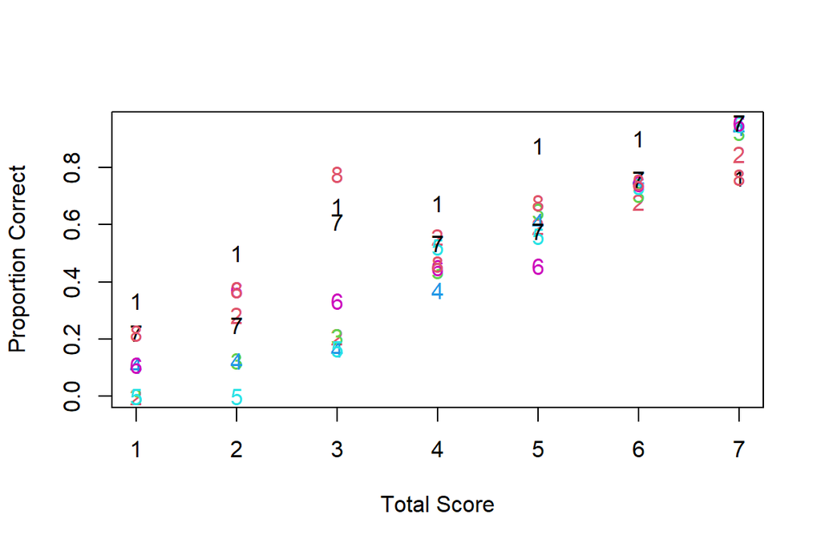

```r
plot(descript(fies))
```

```r
l1 <- ltm(fies ~ z1)
l1
```

```
##
## Call:
## ltm(formula = fies ~ z1)
##
## Coefficients:
##        Dffclt  Dscrmn
## q_422   -1.82    2.89
## q_423   -1.52    4.75
## q_424   -1.47    8.02
## q_425   -1.49    7.04
## q_426   -1.41   17.24
## q_427   -1.50    7.00
## q_428   -1.60    5.16
## q_429   -1.66    3.26
##
## Log.Lik: -3335
```

```r
summary(l1)
```

```
##
## Call:
## ltm(formula = fies ~ z1)
##
## Model Summary:
##  log.Lik  AIC  BIC
##    -3335 6701 6800
##
## Coefficients:
##              value std.err  z.vals
## Dffclt.q_422 -1.82   0.061 -29.779
## Dffclt.q_423 -1.52   0.034 -44.956
## Dffclt.q_424 -1.47   0.048 -30.304
## Dffclt.q_425 -1.49   0.033 -45.111
## Dffclt.q_426 -1.41   0.131 -10.759
## Dffclt.q_427 -1.50   0.036 -42.073
## Dffclt.q_428 -1.60   0.041 -38.816
## Dffclt.q_429 -1.66   0.049 -33.591
## Dscrmn.q_422  2.89   0.226  12.751
## Dscrmn.q_423  4.75   0.499   9.520
## Dscrmn.q_424  8.02   3.109   2.578
## Dscrmn.q_425  7.04   1.229   5.733
## Dscrmn.q_426 17.24  41.591   0.414
## Dscrmn.q_427  7.00   1.238   5.659
## Dscrmn.q_428  5.16   0.552   9.342
## Dscrmn.q_429  3.26   0.252  12.935
##
## Integration:
## method: Gauss-Hermite
## quadrature points: 21
##
## Optimization:
## Convergence: 0
## max(|grad|): 0.023
## quasi-Newton: BFGS
```

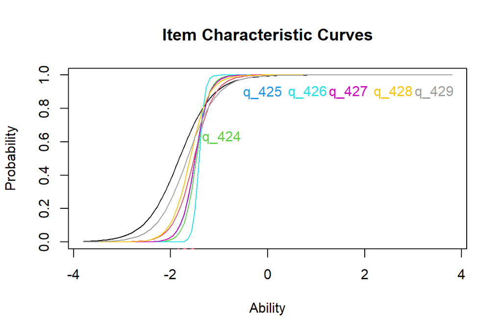

```r
plot(l1, type="ICC")
```

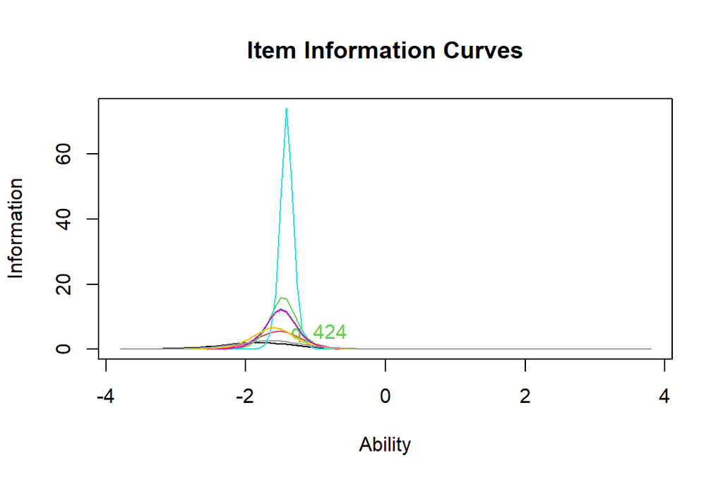

```r
plot(l1, type="IIC")
```

```r
plot(l1_scores, type="loadings")
```

```
## Error in h(simpleError(msg, call)): error in evaluating the argument 'x' in selecting a method for function 'plot': object 'l1_scores' not found
```

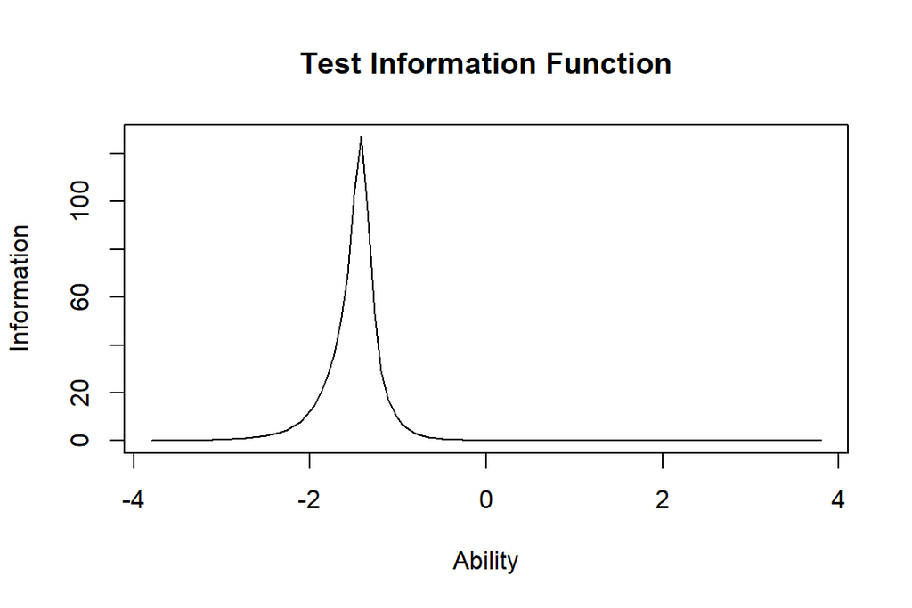

```r
plot(l1,
     type="IIC",
     items=0)
```

```r
person.fit(l1)
```

```
##
## Person-Fit Statistics and P-values
##
## Call:
## ltm(formula = fies ~ z1)
##
## Alternative: Inconsistent response pattern under the estimated model
##
##     q_422 q_423 q_424 q_425 q_426 q_427 q_428 q_429      L0      Lz Pr(<Lz)
## 1       0     0     0     0     0     0     0     0 -0.6700  0.6972  0.7572
## 2       0     0     0     0     0     0     0     1 -2.2650  0.3870  0.6506
## 3       0     0     0     0     0     0     1     0 -3.0579  0.1980  0.5785
## 4       0     0     0     0     0     0     1     1 -3.5434  0.3688  0.6439
## 5       0     0     0     0     0     0    NA     0 -0.6928  0.7859   0.784
## 6       0     0     0     0     0     1     0     0 -4.2156 -0.3675  0.3566
```

[output cut: 128 more lines]

```r
l1_scores <- factor.scores(l1)


l1_scores_dat <- l1_scores$score.dat

sum(l1_scores_dat$Obs)
```

```
## [1] 3563
```

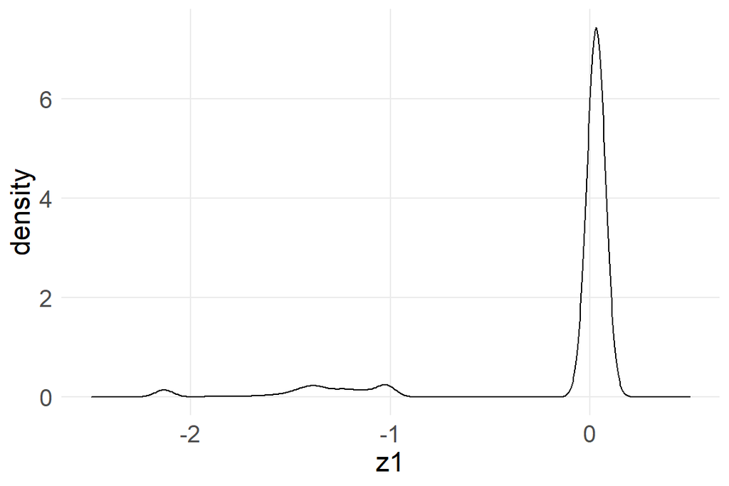

```r
ggplot(l1_scores_dat, aes(z1, weight=Obs)) +
  geom_density() +
  scale_x_continuous(limits=c(-2.5,.5))
```

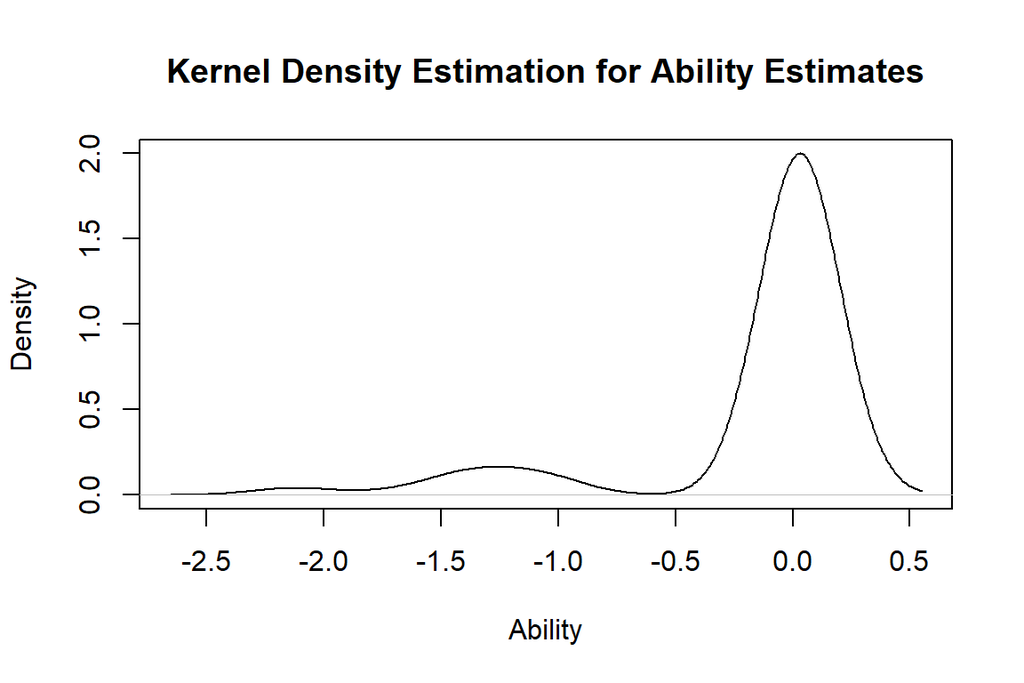

```r
plot(l1_scores)
```

fies_latent <- a$score.dat head(fies_latent)

a$z1

dat <- dat %>% mutate(fies_latent = fies_latent$z1, fies_se = fies_latent$se.z1)

describe(dat$fies_latent)

[output not shown]

```
## Error in stats[1, 3] <- median(x, na.rm = na.rm): number of items to replace is not a multiple of replacement length
```

# 5 Dietary diversity

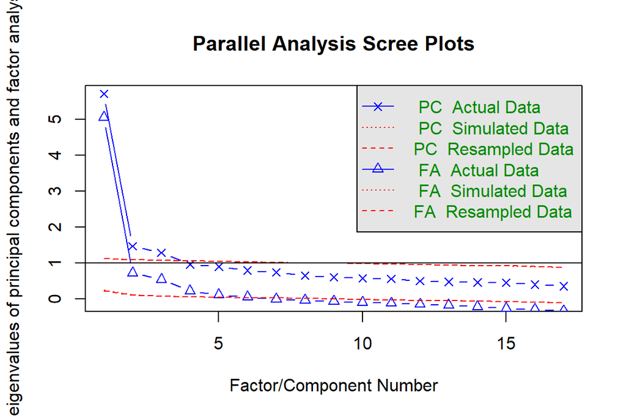

```
## Parallel analysis suggests that the number of factors =  6  and the number of components =  3
```

```r
#frq(dat$fies_raw)

diet <- dat %>%
select(q_403:q_419)

fa.parallel(diet)
```

```r
fa_diet_6 <- fa(diet,
nfactors=6)

fa_diet_6
```

```
## Factor Analysis using method =  minres
## Call: fa(r = diet, nfactors = 6)
## Standardized loadings (pattern matrix) based upon correlation matrix
##         MR1   MR3   MR2   MR5   MR4   MR6   h2   u2 com
## q_403 -0.08  0.22  0.10  0.12  0.13 -0.10 0.12 0.88 3.7
## q_404  0.05 -0.04  0.49  0.14 -0.14  0.21 0.43 0.57 1.8
## q_405  0.03  0.01  0.74 -0.02  0.10 -0.02 0.60 0.40 1.0
## q_406 -0.05  0.34  0.36  0.14 -0.07 -0.21 0.31 0.69 3.1
## q_407  0.03  0.16 -0.01  0.58  0.13  0.02 0.49 0.51 1.3
## q_408  0.15 -0.11  0.19  0.49 -0.05  0.12 0.45 0.55 1.8
## q_409  0.45 -0.01  0.23 -0.01 -0.06  0.23 0.46 0.54 2.1
## q_410  0.76  0.02  0.07 -0.01 -0.05  0.04 0.62 0.38 1.0
## q_411  0.76 -0.02 -0.01  0.04  0.08 -0.06 0.61 0.39 1.0
## q_412  0.62  0.09 -0.09  0.05  0.07 -0.02 0.46 0.54 1.1
## q_413  0.48  0.00  0.06  0.21  0.17 -0.04 0.49 0.51 1.7
## q_414  0.09 -0.03  0.05  0.05  0.71  0.03 0.61 0.39 1.1
## q_415  0.23  0.29  0.19  0.06  0.18  0.04 0.47 0.53 3.6
## q_416  0.45  0.21 -0.02 -0.21  0.07  0.11 0.37 0.63 2.1
## q_417  0.09  0.56  0.05 -0.09  0.20  0.09 0.50 0.50 1.4
## q_418 -0.04  0.24  0.03  0.21  0.18  0.42 0.46 0.54 2.6
## q_419  0.09  0.63 -0.03  0.13 -0.14  0.03 0.47 0.53 1.2
##
##                        MR1  MR3  MR2  MR5  MR4  MR6
## SS loadings           2.72 1.35 1.35 1.02 0.96 0.51
## Proportion Var        0.16 0.08 0.08 0.06 0.06 0.03
## Cumulative Var        0.16 0.24 0.32 0.38 0.44 0.47
## Proportion Explained  0.34 0.17 0.17 0.13 0.12 0.06
## Cumulative Proportion 0.34 0.51 0.69 0.81 0.94 1.00
##
##  With factor correlations of
##      MR1  MR3  MR2  MR5  MR4  MR6
## MR1 1.00 0.41 0.47 0.29 0.53 0.38
## MR3 0.41 1.00 0.21 0.28 0.29 0.19
## MR2 0.47 0.21 1.00 0.43 0.19 0.28
## MR5 0.29 0.28 0.43 1.00 0.21 0.22
## MR4 0.53 0.29 0.19 0.21 1.00 0.13
## MR6 0.38 0.19 0.28 0.22 0.13 1.00
##
## Mean item complexity =  1.9
## Test of the hypothesis that 6 factors are sufficient.
```

[output cut: 8 more lines]

```
## The total number of observations was  3563  with Likelihood Chi Square =  343  with prob <  1.2e-45
##
## Tucker Lewis Index of factoring reliability =  0.955
## RMSEA index =  0.041  and the 90 % confidence intervals are  0.037 0.045
## BIC =  -58.2
## Fit based upon off diagonal values = 1
## Measures of factor score adequacy
##                                                    MR1  MR3  MR2  MR5  MR4
## Correlation of (regression) scores with factors   0.93 0.83 0.85 0.80 0.82
## Multiple R square of scores with factors          0.86 0.69 0.73 0.64 0.68
## Minimum correlation of possible factor scores     0.72 0.38 0.46 0.28 0.35
##                                                     MR6
## Correlation of (regression) scores with factors    0.67
## Multiple R square of scores with factors           0.45
## Minimum correlation of possible factor scores     -0.09
```

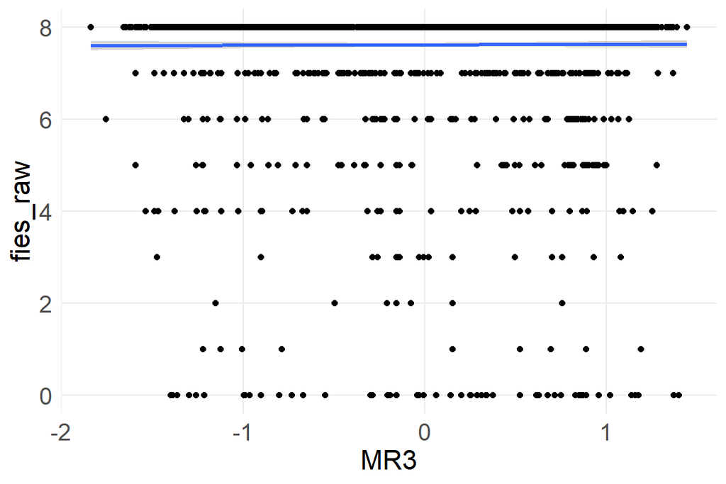

```r
fa_diet_6_scores <- data.frame(fa_diet_6$scores)

dat2 <- dat %>%
cbind(fa_diet_6_scores)

ggplot(dat2, aes(MR3, fies_raw)) +
geom_point() +
stat_smooth(method="lm")
```

```r
l1 <- lm(fies_raw ~ MR1 + MR2 + MR3 + MR4 + MR5 + MR6,
data=dat2)

summary(l1)
```

```
##
## Call:
## lm(formula = fies_raw ~ MR1 + MR2 + MR3 + MR4 + MR5 + MR6, data = dat2)
##
## Residuals:
##    Min     1Q Median     3Q    Max
## -8.005  0.116  0.273  0.482  1.003
##
## Coefficients:
##             Estimate Std. Error t value Pr(>|t|)
## (Intercept)   7.6247     0.0215  354.56  < 2e-16 ***
## MR1           0.1149     0.0429    2.68   0.0074 **
## MR2          -0.0613     0.0374   -1.64   0.1015
## MR3          -0.1283     0.0322   -3.98  7.0e-05 ***
## MR4           0.2674     0.0371    7.21  6.9e-13 ***
## MR5          -0.0785     0.0370   -2.12   0.0340 *
## MR6           0.0205     0.0422    0.49   0.6263
## ---
## Signif. codes:  0 '***' 0.001 '**' 0.01 '*' 0.05 '.' 0.1 ' ' 1
##
## Residual standard error: 1.27 on 3504 degrees of freedom
##   (52 observations deleted due to missingness)
## Multiple R-squared:  0.0373, Adjusted R-squared:  0.0356
## F-statistic: 22.6 on 6 and 3504 DF,  p-value: <2e-16
```

```r
inc <- dat %>%
select(q_401_a_bin,
q_401_b_bin,
q_401_c_bin,
q_401_d_bin,
q_401_e_bin,
q_401_f_bin,
q_401_g_bin,
q_401_h_bin,
q_401_i_bin,
q_401_j_bin,
q_401_k_bin,
q_401_j_bin,
q_401_k_bin,
q_401_l_bin,
q_401_m_bin,
q_401_n_bin,
q_401_o_bin,
q_401_p_bin,
q_401_q_bin,
q_401_r_bin,
q_401_s_bin,
q_401_t_bin,
q_401_u_bin)

str(inc)
```

```
## tibble [3,563 x 21] (S3: tbl_df/tbl/data.frame)
##  $ q_401_a_bin: dbl+lbl [1:3563] 1, 1, 1, 1, 0, 1, 0, 1, 1, 0, 1, 1, 1, 1, 1, 1, 0, 1,...
##    ..@ label       : chr "Q 401_a: Sources of HH food/income - Own farming/crop production (binary)"
##    ..@ format.stata: chr "%10.0g"
##    ..@ labels      : Named num [1:4] 0 1 8 9
##    .. ..- attr(*, "names")= chr [1:4] "No" "Yes" "Don't know" "Refused"
##  $ q_401_b_bin: dbl+lbl [1:3563] 1, 0, 1, 1, 0, 1, 0, 0, 1, 0, 0, 1, 1, 1, 0, 1, 0, 0,...
##    ..@ label       : chr "Q 401_b: Sources of HH food/income - Own cattle production (binary)"
##    ..@ format.stata: chr "%10.0g"
##    ..@ labels      : Named num [1:4] 0 1 8 9
##    .. ..- attr(*, "names")= chr [1:4] "No" "Yes" "Don't know" "Refused"
##  $ q_401_c_bin: dbl+lbl [1:3563] 0, 1, 1, 1, 0, 1, 0, 0, 1, 0, 0, 1, 0, 1, 0, 0, 0, 0,...
##    ..@ label       : chr "Q 401_c: Sources of HH food/income - Own goats production (binary)"
##    ..@ format.stata: chr "%10.0g"
##    ..@ labels      : Named num [1:4] 0 1 8 9
##    .. ..- attr(*, "names")= chr [1:4] "No" "Yes" "Don't know" "Refused"
##  $ q_401_d_bin: dbl+lbl [1:3563] 0, 1, 0, 0, 0, 1, 0, 0, 1, 0, 0, 1, 0, 1, 0, 0, 0, 0,...
##    ..@ label       : chr "Q 401_d: Sources of HH food/income - Own sheep production (binary)"
##    ..@ format.stata: chr "%10.0g"
##    ..@ labels      : Named num [1:4] 0 1 8 9
##    .. ..- attr(*, "names")= chr [1:4] "No" "Yes" "Don't know" "Refused"
##  $ q_401_e_bin: dbl+lbl [1:3563] 0, 1, 1, 0, 1, 0, 1, 0, 0, 1, 1, 1, 0, 1, 0, 1, 0, 1,...
##    ..@ label       : chr "Q 401_e: Sources of HH food/income - Own fishing and sales (binary)"
##    ..@ format.stata: chr "%10.0g"
##    ..@ labels      : Named num [1:4] 0 1 8 9
##    .. ..- attr(*, "names")= chr [1:4] "No" "Yes" "Don't know" "Refused"
##  $ q_401_f_bin: dbl+lbl [1:3563] 0, 0, 1, 0, 0, 0, 0, 0, 0, 0, 0, 0, 0, 0, 0, 0, 0, 0,...
##    ..@ label       : chr "Q 401_f: Sources of HH food/income - Ag wage labor (within the village) (binary)"
##    ..@ format.stata: chr "%10.0g"
##    ..@ labels      : Named num [1:4] 0 1 8 9
##    .. ..- attr(*, "names")= chr [1:4] "No" "Yes" "Don't know" "Refused"
##  $ q_401_g_bin: dbl+lbl [1:3563] 0, 0, 1, 0, 0, 0, 0, 0, 0, 0, 0, 0, 0, 0, 0, 0, 0, 0,...
##    ..@ label       : chr "Q 401_g: Sources of HH food/income - Ag wage labor (outside of village) (binary)"
##    ..@ format.stata: chr "%10.0g"
##    ..@ labels      : Named num [1:4] 0 1 8 9
##    .. ..- attr(*, "names")= chr [1:4] "No" "Yes" "Don't know" "Refused"
##  $ q_401_h_bin: dbl+lbl [1:3563] 0, 0, 1, 0, 0, 0, 0, 0, 0, 0, 0, 0, 0, 0, 0, 0, 0, 0,...
##    ..@ label       : chr "Q 401_h: Sources of HH food/income - Non-ag wage labor (within village) (binary)"
##    ..@ format.stata: chr "%10.0g"
##    ..@ labels      : Named num [1:4] 0 1 8 9
```

[output cut: 51 more lines]

```
##  $ q_401_s_bin: dbl+lbl [1:3563] 0, 0, 0, 1, 0, 0, 0, 0, 0, 0, 0, 0, 0, 0, 0, 0, 0, 0,...
##    ..@ label       : chr "Q 401_s: Sources of HH food/income - Gifts / inheritance (binary)"
##    ..@ format.stata: chr "%10.0g"
##    ..@ labels      : Named num [1:4] 0 1 8 9
##    .. ..- attr(*, "names")= chr [1:4] "No" "Yes" "Don't know" "Refused"
##  $ q_401_t_bin: dbl+lbl [1:3563] 1, 1, 1, 1, 0, 0, 0, 0, 0, 0, 1, 0, 1, 0, 1, 1, 0, 0,...
##    ..@ label       : chr "Q 401_t: Sources of HH food/income - Safety net food / cash assistance (binary)"
##    ..@ format.stata: chr "%10.0g"
##    ..@ labels      : Named num [1:4] 0 1 8 9
##    .. ..- attr(*, "names")= chr [1:4] "No" "Yes" "Don't know" "Refused"
##  $ q_401_u_bin: dbl+lbl [1:3563] 0, 0, 0, 0, 0, 0, 0, 1, 1, 0, 0, 0, 0, 0, 0, 1, 0, 0,...
##    ..@ label       : chr "Q 401_u: Sources of HH food/income - Other (binary)"
##    ..@ format.stata: chr "%10.0g"
##    ..@ labels      : Named num [1:4] 0 1 8 9
##    .. ..- attr(*, "names")= chr [1:4] "No" "Yes" "Don't know" "Refused"
```

```r
head(inc)
```

Table 5.1:

| q_401_a_bin | q_401_b_bin | q_401_c_bin | q_401_d_bin | q_401_e_bin | q_401_f_bin | q_401_g_bin | q_401_h_bin | q_401_i_bin | q_401_j_bin | q_401_k_bin | q_401_l_bin | q_401_m_bin | q_401_n_bin | q_401_o_bin | q_401_p_bin | q_401_q_bin | q_401_r_bin | q_401_s_bin | q_401_t_bin | q_401_u_bin |
| --- | --- | --- | --- | --- | --- | --- | --- | --- | --- | --- | --- | --- | --- | --- | --- | --- | --- | --- | --- | --- |
| 1 | 1 | 0 | 0 | 0 | 0 | 0 | 0 | 0 | 0 | 0 | 0 | 0 | 0 | 0 | 0 | 0 | 0 | 0 | 1 | 0 |
| 1 | 0 | 1 | 1 | 1 | 0 | 0 | 0 | 0 | 0 | 0 | 0 | 0 | 0 | 0 | 0 | 0 | 0 | 0 | 1 | 0 |
| 1 | 1 | 1 | 0 | 1 | 1 | 1 | 1 | 0 | 0 | 0 | 0 | 0 | 0 | 0 | 0 | 0 | 0 | 0 | 1 | 0 |
| 1 | 1 | 1 | 0 | 0 | 0 | 0 | 0 | 0 | 0 | 0 | 0 | 0 | 0 | 0 | 0 | 0 | 0 | 1 | 1 | 0 |
| 0 | 0 | 0 | 0 | 1 | 0 | 0 | 0 | 0 | 0 | 0 | 0 | 0 | 0 | 0 | 0 | 0 | 0 | 0 | 0 | 0 |
| 1 | 1 | 1 | 1 | 0 | 0 | 0 | 0 | 0 | 0 | 0 | 0 | 0 | 0 | 0 | 0 | 0 | 0 | 0 | 0 | 0 |

```r
fa.parallel(inc
, cor="tet")
```

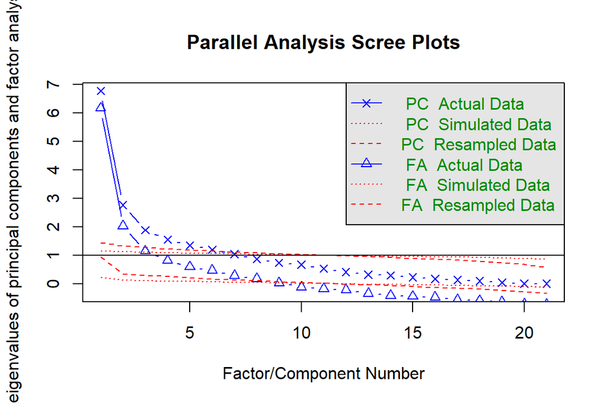

```
## Parallel analysis suggests that the number of factors =  8  and the number of components =  6
```

```r
fa_inc_6 <- fa(inc,
nfactors=6)

fa_inc_6
```

```
## Factor Analysis using method =  minres
## Call: fa(r = inc, nfactors = 6)
## Standardized loadings (pattern matrix) based upon correlation matrix
##               MR2   MR1   MR3   MR6   MR5   MR4    h2   u2 com
## q_401_a_bin  0.46  0.03  0.02 -0.11 -0.03  0.09 0.211 0.79 1.2
## q_401_b_bin  0.63 -0.03 -0.06  0.03 -0.05  0.00 0.399 0.60 1.0
## q_401_c_bin  0.72 -0.04  0.00 -0.02  0.04 -0.02 0.496 0.50 1.0
## q_401_d_bin  0.71  0.03  0.04  0.04  0.00  0.01 0.556 0.44 1.0
## q_401_e_bin  0.01  0.08 -0.03  0.38 -0.02  0.02 0.171 0.83 1.1
## q_401_f_bin  0.22  0.43  0.08  0.15  0.21 -0.09 0.505 0.49 2.5
## q_401_g_bin  0.01  0.79  0.02 -0.02 -0.04  0.05 0.632 0.37 1.0
## q_401_h_bin -0.13  0.34  0.00  0.23  0.25 -0.14 0.315 0.69 3.5
## q_401_i_bin -0.04  0.67  0.00 -0.03  0.03  0.05 0.462 0.54 1.0
## q_401_j_bin -0.02  0.05 -0.01  0.00  0.02  0.56 0.331 0.67 1.0
## q_401_k_bin  0.00 -0.06  0.03  0.64 -0.01  0.05 0.400 0.60 1.0
## q_401_l_bin  0.23  0.03 -0.01  0.36  0.16  0.08 0.352 0.65 2.3
## q_401_m_bin  0.09  0.11  0.57  0.07 -0.15 -0.03 0.388 0.61 1.3
## q_401_n_bin -0.04  0.02  0.68  0.02 -0.08  0.00 0.452 0.55 1.0
## q_401_o_bin  0.05  0.08  0.48 -0.07  0.19 -0.02 0.326 0.67 1.5
## q_401_p_bin -0.05 -0.12  0.51 -0.04  0.29  0.07 0.358 0.64 1.8
## q_401_q_bin  0.04  0.05  0.00  0.09  0.00  0.54 0.348 0.65 1.1
## q_401_r_bin -0.07  0.02  0.08 -0.03  0.12  0.19 0.061 0.94 2.5
## q_401_s_bin  0.04  0.05  0.00  0.12  0.53  0.04 0.376 0.62 1.2
## q_401_t_bin  0.09  0.14 -0.10 -0.06  0.36  0.08 0.186 0.81 1.8
## q_401_u_bin -0.06 -0.04 -0.04 -0.08  0.07  0.00 0.019 0.98 3.9
##
##                        MR2  MR1  MR3  MR6  MR5  MR4
## SS loadings           1.85 1.61 1.35 0.94 0.84 0.74
## Proportion Var        0.09 0.08 0.06 0.04 0.04 0.04
## Cumulative Var        0.09 0.16 0.23 0.27 0.31 0.35
## Proportion Explained  0.25 0.22 0.18 0.13 0.11 0.10
## Cumulative Proportion 0.25 0.47 0.66 0.78 0.90 1.00
##
##  With factor correlations of
##      MR2  MR1  MR3  MR6  MR5  MR4
## MR2 1.00 0.22 0.09 0.39 0.15 0.17
## MR1 0.22 1.00 0.28 0.33 0.29 0.22
## MR3 0.09 0.28 1.00 0.13 0.18 0.06
## MR6 0.39 0.33 0.13 1.00 0.29 0.13
## MR5 0.15 0.29 0.18 0.29 1.00 0.08
```

[output cut: 8 more lines]

```
## The root mean square of the residuals (RMSR) is  0.03
## The df corrected root mean square of the residuals is  0.04
##
## The harmonic number of observations is  3563 with the empirical chi square  1174  with prob <  2.6e-183
## The total number of observations was  3563  with Likelihood Chi Square =  1359  with prob <  2.5e-220
##
## Tucker Lewis Index of factoring reliability =  0.802
## RMSEA index =  0.06  and the 90 % confidence intervals are  0.057 0.063
## BIC =  549
## Fit based upon off diagonal values = 0.97
## Measures of factor score adequacy
##                                                    MR2  MR1  MR3  MR6  MR5  MR4
## Correlation of (regression) scores with factors   0.88 0.88 0.83 0.78 0.75 0.73
## Multiple R square of scores with factors          0.78 0.78 0.69 0.61 0.56 0.53
## Minimum correlation of possible factor scores     0.56 0.55 0.38 0.22 0.11 0.06
```